# Dietary Patterns and Hypertension Prediction Using NHANES Data | Option 2

Maya Arnott

Machine Learning | May 4th, 2026

# 1 Introduction

Hypertension affects nearly half of U.S. adults and is a leading modifiable risk factor for cardiovascular disease, stroke, and kidney failure. Despite its prevalence, a substantial proportion of cases go undiagnosed. This is often because clinical blood pressure measurement requires a healthcare visit that many individuals do not access regularly. A prediction model trained on dietary patterns and demographic characteristics could support early identification of at-risk individuals in settings where direct measurement is unavailable or costly, and could help clarify whether diet plays an independent predictive role beyond established risk factors such as age and BMI.

Using NHANES, a nationally representative survey of U.S. adults spanning 1988–2018, this analysis addresses the following research question: **Do PCA-derived dietary pattern scores help predict hypertension status in a held-out test set, when including key demographic and behavioral covariates?** Four classification models are compared: logistic regression (baseline), LASSO logistic regression, random forest, and XGBoost. All models are trained on a 70% training set and evaluated on a 30% held-out test set that was never seen during model development.

# 2 Data Loading & Preparation

NHANES data spanning 1988–2018 were loaded and joined into a single analytic dataset. For the purposes of this study, hypertension was defined as a measured systolic BP ≥ 130 mmHg, diastolic BP ≥ 80 mmHg, or self-reported antihypertensive medication use. Any missing covariate data (education, income, smoking, and BMI) are imputed using predictive mean matching via `mice` (m = 5 imputations; first completed dataset used), given that less than 7% of these variables were missing. Any individuals with missing hypertension data were dropped from the dataset. After restriction and imputation, 56367 individuals remain.

```r
load("data/w - nhanes_1988_2018.RData")

# dietary subset — one observation per participant
dietary_sub <- dietary_clean |>
  filter(survey_day == 1) |>
  select(SEQN,
         DRXTKCAL, DRXTPROT, DRXTCARB, DRXTTFAT, DRXTSFAT,
         DRXTMFAT, DRXTPFAT, DRXTSODI, DRXTPOTA, DRXTCALC,
         DRXTMAGN, DRXTFIBE, DRXTVC, DRXTVB12, DRXTFOLA,
         DRXTIRON, DRXTZINC) |>
  group_by(SEQN) |>
  slice(1) |>
  ungroup()

# demographics subset
demographics_subset <- demographics_clean |>
  filter(SDDSRVYR >= 1 & SDDSRVYR <= 10) |>
  mutate(race = coalesce(RIDRETH3, RIDRETH1)) |>
  select(SEQN, SDDSRVYR, RIDAGEYR, RIAGENDR, race, DMDEDUC2, INDFMPIR)

# questionnaire subset
questionnaire_subset <- questionnaire_clean |>
  select(SEQN, ALQ130, PAQ650) |>
  group_by(SEQN) |>
  slice(1) |>
  ungroup()

# mortality subset
mortality_subset <- mortality_clean |>
  filter(ELIGSTAT == 1) |>
  select(SEQN, MORTSTAT, PERMTH_INT, UCOD_LEADING) |>
  group_by(SEQN) |>
  arrange(desc(MORTSTAT), desc(PERMTH_INT)) |>
  slice(1) |>
  ungroup()

# smoking data (raw numeric codes, all cycles)
smoke_list <- list(
  nhanes("SMQ",   translated = FALSE),
  nhanes("SMQ_B", translated = FALSE),
  nhanes("SMQ_C", translated = FALSE),
  nhanes("SMQ_D", translated = FALSE),
  nhanes("SMQ_E", translated = FALSE),
  nhanes("SMQ_F", translated = FALSE),
  nhanes("SMQ_G", translated = FALSE),
  nhanes("SMQ_H", translated = FALSE),
  nhanes("SMQ_I", translated = FALSE),
  nhanes("SMQ_J", translated = FALSE)
)

smoke_all <- smoke_list |>
  map(~mutate(.x, across(everything(), as.character))) |>
  bind_rows() |>
  select(SEQN, SMQ020, SMQ040) |>
  mutate(
    SEQN   = as.numeric(SEQN),
    SMQ020 = as.numeric(SMQ020),
    SMQ040 = as.numeric(SMQ040)
  ) |>
  mutate(smoke_status = case_when(
    SMQ020 == 2               ~ "Never",
    SMQ020 == 1 & SMQ040 == 3 ~ "Former",
    SMQ020 == 1 & SMQ040 == 2 ~ "Current (some days)",
    SMQ020 == 1 & SMQ040 == 1 ~ "Current (daily)",
    TRUE                      ~ NA_character_
  ) |> factor(levels = c("Never", "Former", "Current (some days)", "Current (daily)")))

# BMI data (all cycles)
bmx_list <- list(
  nhanes("BMX",   translated = FALSE),
  nhanes("BMX_B", translated = FALSE),
  nhanes("BMX_C", translated = FALSE),
  nhanes("BMX_D", translated = FALSE),
  nhanes("BMX_E", translated = FALSE),
  nhanes("BMX_F", translated = FALSE),
  nhanes("BMX_G", translated = FALSE),
  nhanes("BMX_H", translated = FALSE),
  nhanes("BMX_I", translated = FALSE),
  nhanes("BMX_J", translated = FALSE)
)

bmx_all <- bmx_list |>
  map(~mutate(.x, across(everything(), as.character))) |>
  bind_rows() |>
  select(SEQN, BMXBMI, BMXWAIST) |>
  mutate(
    SEQN     = as.numeric(SEQN),
    BMXBMI   = as.numeric(BMXBMI),
    BMXWAIST = as.numeric(BMXWAIST)
  ) |>
  group_by(SEQN) |>
  slice(1) |>
  ungroup()

# blood pressure exam data (all cycles)
bpx_list <- list(
  nhanes("BPX",   translated = FALSE),
  nhanes("BPX_B", translated = FALSE),
  nhanes("BPX_C", translated = FALSE),
  nhanes("BPX_D", translated = FALSE),
  nhanes("BPX_E", translated = FALSE),
  nhanes("BPX_F", translated = FALSE),
  nhanes("BPX_G", translated = FALSE),
  nhanes("BPX_H", translated = FALSE),
  nhanes("BPX_I", translated = FALSE),
  nhanes("BPX_J", translated = FALSE)
)

bpx_all <- bpx_list |>
  map(~mutate(.x, across(everything(), as.numeric))) |>
  bind_rows() |>
  rowwise() |>
  mutate(
    SBP_mean = mean(c(BPXSY1, BPXSY2, BPXSY3, BPXSY4), na.rm = TRUE),
    DBP_mean = mean(c(BPXDI1, BPXDI2, BPXDI3, BPXDI4), na.rm = TRUE)
  ) |>
  ungroup() |>
  select(SEQN, SBP_mean, DBP_mean) |>
  group_by(SEQN) |>
  slice(1) |>
  ungroup()

bpq <- questionnaire_clean |>
  select(SEQN, BPQ020, BPQ040A) |>
  group_by(SEQN) |>
  slice(1) |>
  ungroup()

# define hypertension outcome
htn_df <- bpx_all |>
  left_join(bpq, by = "SEQN") |>
  mutate(
    hypertension = case_when(
      (!is.na(SBP_mean) & SBP_mean >= 130) |
      (!is.na(DBP_mean) & DBP_mean >= 80)  ~ 1,
      BPQ040A == 1                          ~ 1,
      TRUE                                  ~ 0
    )
  )

# join all subsets
final_df <- demographics_subset |>
  left_join(questionnaire_subset, by = "SEQN") |>
  left_join(mortality_subset,     by = "SEQN") |>
  left_join(smoke_all,            by = "SEQN") |>
  left_join(bmx_all,              by = "SEQN") |>
  left_join(htn_df |> select(SEQN, hypertension), by = "SEQN")

# restrict to adults with a hypertension value
final_df <- final_df |>
  filter(RIDAGEYR >= 18) |>
  filter(!is.na(hypertension)) |>
  select(-SMQ020, -SMQ040, -ALQ130, -PAQ650, -MORTSTAT, -PERMTH_INT, -UCOD_LEADING)

# impute missing covariates
to_impute <- final_df |>
  select(SEQN, DMDEDUC2, INDFMPIR, smoke_status, BMXBMI, BMXWAIST) |>
  mutate(
    smoke_status = factor(smoke_status),
    DMDEDUC2     = factor(DMDEDUC2)
  )

imputed    <- mice(to_impute, m = 5, method = "pmm", seed = 123, printFlag = FALSE)
imputed_df <- complete(imputed, 1)

final_complete <- final_df |>
  select(-DMDEDUC2, -INDFMPIR, -smoke_status, -BMXBMI, -BMXWAIST) |>
  left_join(imputed_df, by = "SEQN")
```

```r
cat("Analytic N after restriction and imputation:", nrow(final_complete), "\n")
```

```
## Analytic N after restriction and imputation: 56367
```

# 3 PCA Analysis on Dietary Patterns

Dietary nutrient intakes are structurally intercorrelated; people who eat more overall tend to have higher values across nearly every nutrient, and fat subtypes (saturated, mono-, polyunsaturated) cluster together by definition. Entering all 17 raw nutrients as predictors in a regression model would cause severe multicollinearity, inflating standard errors and making it very difficult to interpret coefficients. To address this problem, principal component analysis (PCA) was applied, rotating the 17 correlated variables into a smaller set of orthogonal (uncorrelated) components that collectively summarize the underlying dietary patterns. Using PCA to derive dietary patterns is a well-established approach in nutritional epidemiology: it allows the investigator to name interpretable dietary axes (such as overall intake volume or diet quality) rather than interpreting individual nutrients in isolation, and it substantially reduces the dimensionality of the features.

## 3.1 Nutrient Correlation Structure

The heatmap below shows the pairwise Pearson correlations among the 17 dietary variables. Many of the Pearson r values are around 0.7-0.8, which motivates the use of PCA.

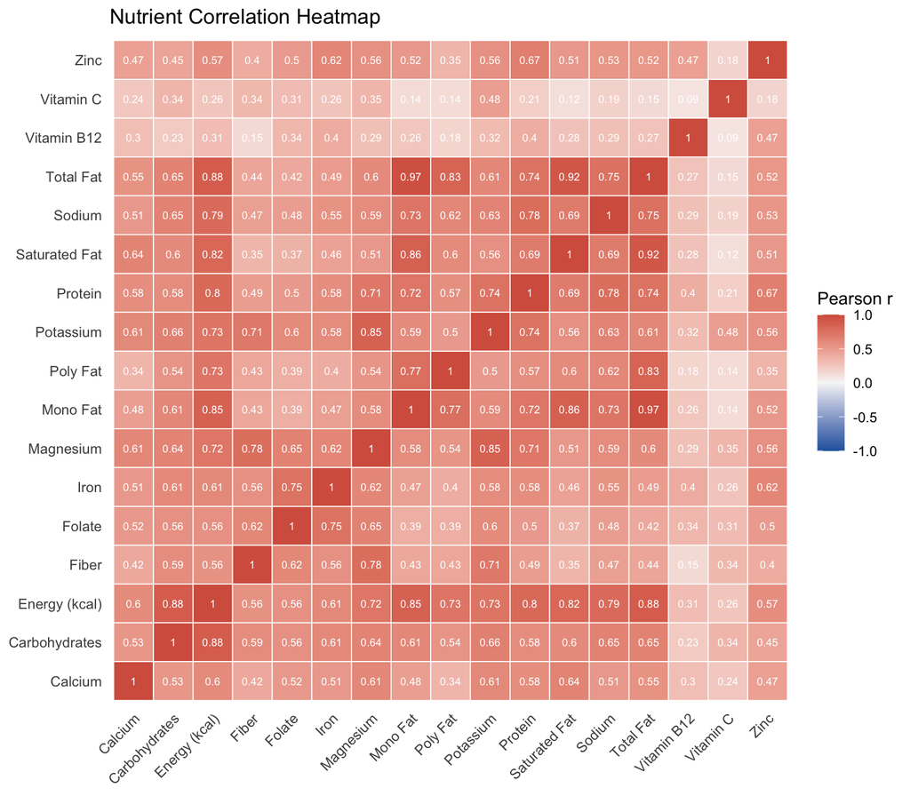

Pairwise Pearson correlations among 17 dietary nutrient variables. Strong positive correlations (dark red) indicate clusters of co-varying nutrients that PCA will consolidate into components.

```r
# create dietary_pca here so it is available for the PCA chunk below
dietary_pca <- dietary_sub |>
  filter(SEQN %in% final_complete$SEQN) |>
  drop_na()

final_complete <- final_complete |>
  filter(SEQN %in% dietary_pca$SEQN)

nutrient_labels <- c(
  DRXTKCAL = "Energy (kcal)",  DRXTPROT = "Protein",
  DRXTCARB = "Carbohydrates",  DRXTTFAT = "Total Fat",
  DRXTSFAT = "Saturated Fat",  DRXTMFAT = "Mono Fat",
  DRXTPFAT = "Poly Fat",       DRXTSODI = "Sodium",
  DRXTPOTA = "Potassium",      DRXTCALC = "Calcium",
  DRXTMAGN = "Magnesium",      DRXTFIBE = "Fiber",
  DRXTVC   = "Vitamin C",      DRXTVB12 = "Vitamin B12",
  DRXTFOLA = "Folate",         DRXTIRON = "Iron",
  DRXTZINC = "Zinc"
)

cor_mat <- dietary_pca |>
  select(-SEQN) |>
  cor(use = "pairwise.complete.obs")

colnames(cor_mat) <- nutrient_labels[colnames(cor_mat)]
rownames(cor_mat) <- nutrient_labels[rownames(cor_mat)]

cor_long <- cor_mat |>
  as.data.frame() |>
  rownames_to_column("var1") |>
  pivot_longer(-var1, names_to = "var2", values_to = "r")

ggplot(cor_long, aes(x = var1, y = var2, fill = r)) +
  geom_tile(color = "white", linewidth = 0.3) +
  geom_text(aes(label = round(r, 2)), size = 2.4, color = "white") +
  scale_fill_gradient2(
    low      = "#2166ac",
    mid      = "#f7f7f7",
    high     = "#d6604d",
    midpoint = 0,
    limits   = c(-1, 1),
    name     = "Pearson r"
  ) +
  theme_minimal(base_size = 11) +
  theme(
    axis.text.x  = element_text(angle = 45, hjust = 1, size = 9),
    axis.text.y  = element_text(size = 9),
    axis.title   = element_blank(),
    panel.grid   = element_blank(),
    legend.position = "right"
  ) +
  labs(title = "Nutrient Correlation Heatmap")
```

```r
pca_input  <- dietary_pca |> select(-SEQN) |> as.matrix()
pca_result <- prcomp(pca_input, center = TRUE, scale. = TRUE)

# variance explained
var_explained <- pca_result$sdev^2 / sum(pca_result$sdev^2)
cum_var       <- cumsum(var_explained)

cat("Variance explained — PC1:", round(var_explained[1]*100, 2), "%\n")
```

```
## Variance explained — PC1: 57.31 %
```

```r
cat("Variance explained — PC2:", round(var_explained[2]*100, 2), "%\n")
```

```
## Variance explained — PC2: 10.13 %
```

```r
cat("Cumulative (PC1 + PC2):  ", round(cum_var[2]*100, 2), "%\n")
```

```
## Cumulative (PC1 + PC2):   67.44 %
```

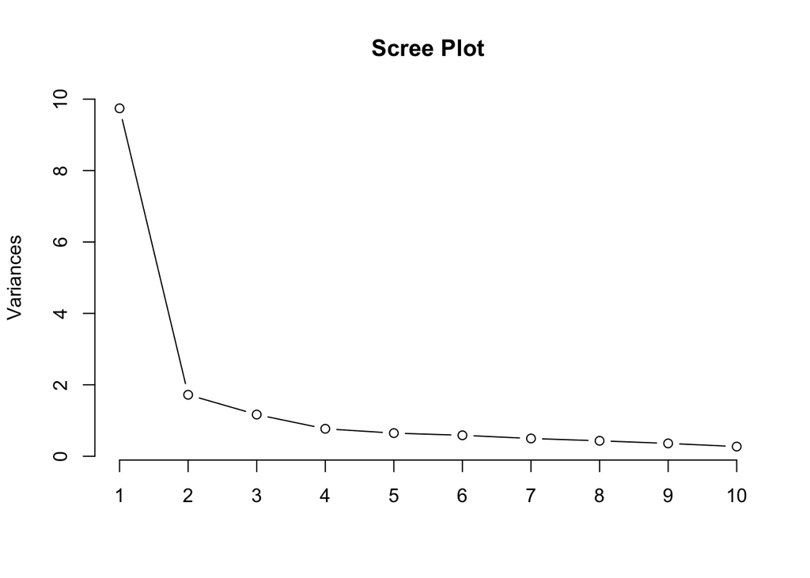

Scree plot of PCA. The elbow at PC2 supports retaining two components.

```r
plot(pca_result, type = "l", main = "Scree Plot")
```

```r
# sign-flipped so higher intake = higher PC1, plant-rich = higher PC2
pca_scores        <- as.data.frame(pca_result$x)
pca_scores$SEQN   <- dietary_pca$SEQN
pca_scores$PC1    <- -1 * pca_scores$PC1
pca_scores$PC2    <- -1 * pca_scores$PC2
pca_scores        <- pca_scores |> select(PC1, PC2, SEQN)

final_complete <- final_complete |> left_join(pca_scores, by = "SEQN")

# loadings for first two components
round(pca_result$rotation[, 1:2], 3)
```

```
##             PC1    PC2
## DRXTKCAL -0.300  0.137
## DRXTPROT -0.275  0.060
## DRXTCARB -0.258 -0.048
## DRXTTFAT -0.280  0.341
## DRXTSFAT -0.259  0.320
## DRXTMFAT -0.269  0.337
## DRXTPFAT -0.231  0.282
## DRXTSODI -0.264  0.144
## DRXTPOTA -0.270 -0.208
## DRXTCALC -0.224 -0.085
## DRXTMAGN -0.268 -0.221
## DRXTFIBE -0.219 -0.307
## DRXTVC   -0.109 -0.375
## DRXTVB12 -0.131 -0.120
## DRXTFOLA -0.222 -0.345
## DRXTIRON -0.237 -0.257
## DRXTZINC -0.223 -0.097
```

The scree plot shows an elbow after PC2. Together, PC1 and PC2 explain **67.4%** of the variability in dietary patterns. For these two reasons, PC1 and PC2 were used in all models to capture dietary patterns.

**PC1 — Overall dietary volume:** This component loads positively on nearly all nutrients, capturing total food/energy intake (capturing *how much* people eat).

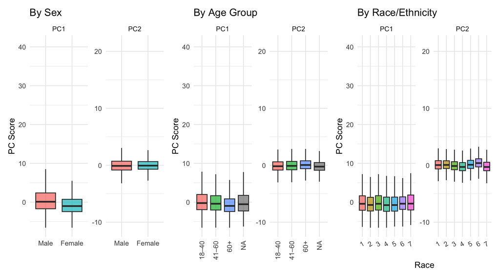

PC1 and PC2 scores by race/ethnicity, sex, and age group.

```r
pca_demo <- final_complete |>
  select(PC1, PC2, RIAGENDR, race, RIDAGEYR) |>
  mutate(
    age_group = cut(RIDAGEYR, breaks = c(18, 40, 60, Inf),
                    labels = c("18–40", "41–60", "60+")),
    sex       = factor(RIAGENDR, labels = c("Male", "Female")),
    race      = factor(race)
  )

# by race/ethnicity
p_race <- pca_demo |>
  pivot_longer(c(PC1, PC2), names_to = "component", values_to = "score") |>
  ggplot(aes(x = race, y = score, fill = race)) +
  geom_boxplot(alpha = 0.7, outlier.shape = NA) +
  facet_wrap(~component, scales = "free_y") +
  theme_minimal() +
  labs(title = "By Race/Ethnicity", x = "Race", y = "PC Score") +
  theme(axis.text.x = element_text(angle = 30, hjust = 1),
        legend.position = "none")

# by sex
p_sex <- pca_demo |>
  pivot_longer(c(PC1, PC2), names_to = "component", values_to = "score") |>
  ggplot(aes(x = sex, y = score, fill = sex)) +
  geom_boxplot(alpha = 0.7, outlier.shape = NA) +
  facet_wrap(~component, scales = "free_y") +
  theme_minimal() +
  labs(title = "By Sex", x = NULL, y = "PC Score") +
  theme(legend.position = "none")

# by age group
p_age <- pca_demo |>
  pivot_longer(c(PC1, PC2), names_to = "component", values_to = "score") |>
  ggplot(aes(x = age_group, y = score, fill = age_group)) +
  geom_boxplot(alpha = 0.7, outlier.shape = NA) +
  facet_wrap(~component, scales = "free_y") +
  theme_minimal() +
  labs(title = "By Age Group", x = NULL, y = "PC Score") +
  theme(legend.position = "none",
        axis.text.x = element_text(angle = 90, hjust = 1, vjust = 0.5))

p_sex | p_age | p_race
```

PC1 was slightly elevated in males compared to females, which is consistent with known sex differences in caloric intake. Across age and race/ethnicity, the median’s for PC1 are fairly consistent. PC2 scores were largely similar across sex, age groups, and race/ethnicity, which supports the use of PC2 as an independent predictor of hypertension.

# 4 Models

## 4.1 Setup and Feature Matrix

```r
model_df <- final_complete |>
  select(PC1, PC2, SDDSRVYR, RIDAGEYR,
         RIAGENDR, race, hypertension,
         DMDEDUC2, INDFMPIR, smoke_status,
         BMXBMI) |>
  mutate(
    hypertension = factor(hypertension, levels = c(0, 1),
                          labels = c("Not hypertensive", "Hypertensive")),
    RIAGENDR     = factor(RIAGENDR),
    race         = factor(race),
    DMDEDUC2     = factor(DMDEDUC2),
    smoke_status = factor(smoke_status),
    BMXBMI       = as.numeric(BMXBMI)
  ) |>
  drop_na()

cat("Final analytic N:", nrow(model_df), "\n")
```

```
## Final analytic N: 52365
```

```r
model_df |> count(hypertension) |> mutate(pct = round(n / sum(n) * 100, 1))
```

| hypertension | n | pct |
| --- | --- | --- |
| Not hypertensive | 27274 | 52.1 |
| Hypertensive | 25091 | 47.9 |

## 4.2 Train / Test Split

Data were split 70% training / 30% testing, stratified on hypertension status.

```r
set.seed(123)
data_split    <- initial_split(model_df, prop = 0.70, strata = hypertension)
training_data <- training(data_split)
testing_data  <- testing(data_split)

cat("--- Training set ---\n")
```

```
## --- Training set ---
```

```r
training_data |> count(hypertension) |> mutate(pct = round(n / sum(n) * 100, 1))
```

| hypertension | n | pct |
| --- | --- | --- |
| Not hypertensive | 19091 | 52.1 |
| Hypertensive | 17563 | 47.9 |

```r
cat("--- Testing set ---\n")
```

```
## --- Testing set ---
```

```r
testing_data |> count(hypertension) |> mutate(pct = round(n / sum(n) * 100, 1))
```

| hypertension | n | pct |
| --- | --- | --- |
| Not hypertensive | 8183 | 52.1 |
| Hypertensive | 7528 | 47.9 |

## 4.3 Variable Descriptions

| Variable | Description | Type | Notes |
| --- | --- | --- | --- |
| `PC1` | Dietary volume | Continuous (PCA-derived) | Overall food/energy intake: how much a person eats |
| `PC2` | Diet quality | Continuous (PCA-derived) | Fat vs. micronutrient pattern: what kind of diet a person eats |
| `SDDSRVYR` | Survey cycle | Continuous | 1–10, corresponding to 1999–2018 two-year NHANES cycles, controls for secular trends |
| `RIDAGEYR` | Age | Continuous | Age in years |
| `RIAGENDR` | Sex | Factor | 1 = Male (reference), 2 = Female |
| `race` | Race/ethnicity | Factor | 1 = Mexican American (ref), 2 = Other Hispanic, 3 = NH White, 4 = NH Black, 5 = NH Asian, 6 = NH Multiracial, 7 = Other |
| `DMDEDUC2` | Education | Factor | 1 = Less than 9th grade (ref), 2 = 9–11th grade, 3 = HS graduate/GED, 4 = Some college/AA, 5 = College graduate or above, 7 = Refused, 9 = Don’t know |
| `INDFMPIR` | Income-to-poverty ratio | Continuous | Higher values indicate higher income relative to the federal poverty line |
| `smoke_status` | Smoking status | Factor | Never (reference), Former, Current (some days), Current (daily) |
| `BMXBMI` | BMI | Continuous | Body mass index in kg/m² |

## 4.4 Logistic Regression (Baseline)

A standard logistic regression model serves as the interpretable baseline model. An optimal classification threshold was selected via the Youden’s J statistic on the ROC curve.

```r
log_model <- glm(hypertension ~ ., data = training_data, family = binomial())
summary(log_model)
```

```
##
## Call:
## glm(formula = hypertension ~ ., family = binomial(), data = training_data)
##
## Coefficients:
##                                   Estimate Std. Error z value Pr(>|z|)
## (Intercept)                     -4.4487042  0.0819862 -54.262  < 2e-16 ***
## PC1                             -0.0225281  0.0040536  -5.558 2.74e-08 ***
## PC2                             -0.0088665  0.0095210  -0.931  0.35172
## SDDSRVYR                         0.0014979  0.0046205   0.324  0.74580
## RIDAGEYR                         0.0572019  0.0007509  76.176  < 2e-16 ***
## RIAGENDR2                       -0.3978762  0.0253675 -15.685  < 2e-16 ***
## race2                           -0.0113796  0.0515130  -0.221  0.82516
## race3                            0.1085555  0.0377697   2.874  0.00405 **
## race4                            0.5526152  0.0408084  13.542  < 2e-16 ***
## race5                            0.3756693  0.0833259   4.508 6.53e-06 ***
## race6                            0.3361202  0.0669284   5.022 5.11e-07 ***
## race7                            0.4298462  0.1039385   4.136 3.54e-05 ***
## DMDEDUC22                        0.0563835  0.0489324   1.152  0.24921
## DMDEDUC23                        0.0318390  0.0467042   0.682  0.49542
## DMDEDUC24                       -0.0370465  0.0468663  -0.790  0.42925
## DMDEDUC25                       -0.2414228  0.0521576  -4.629 3.68e-06 ***
## DMDEDUC27                        0.4719557  0.5818223   0.811  0.41727
## DMDEDUC29                        0.3154033  0.4420133   0.714  0.47550
## INDFMPIR                         0.0009220  0.0087230   0.106  0.91582
## smoke_statusFormer              -0.0724972  0.0310268  -2.337  0.01946 *
## smoke_statusCurrent (some days)  0.0025703  0.0636914   0.040  0.96781
## smoke_statusCurrent (daily)      0.0394908  0.0348952   1.132  0.25776
## BMXBMI                           0.0583986  0.0018889  30.917  < 2e-16 ***
## ---
## Signif. codes:  0 '***' 0.001 '**' 0.01 '*' 0.05 '.' 0.1 ' ' 1
##
## (Dispersion parameter for binomial family taken to be 1)
##
##     Null deviance: 50750  on 36653  degrees of freedom
## Residual deviance: 40595  on 36631  degrees of freedom
## AIC: 40641
##
## Number of Fisher Scoring iterations: 4
```

```r
log_probs <- predict(log_model, testing_data, type = "response")
log_roc   <- roc(testing_data$hypertension, log_probs,
                 levels = c("Not hypertensive", "Hypertensive"))

cat("Logistic Regression AUC:", round(auc(log_roc), 4), "\n")
```

```
## Logistic Regression AUC: 0.798
```

```r
opt_threshold <- coords(log_roc, "best", ret = "threshold")
cat("Optimal threshold (Youden's J):", round(opt_threshold$threshold, 3), "\n")
```

```
## Optimal threshold (Youden's J): 0.444
```

Predictors `PC1`, `RIDAGEYR`, `RIAGENDR2`, `race3`, `race4`, `race5`, `race6`, `race7`, `DMDEDUC25`, `smoke_statusFormer`, and `BMXBMI` were all identified as significant predictors of hypertension diagnosis (p-val < 0.05). PC2 (diet quality) was not statistically significant, suggesting that dietary composition does not independently predict hypertension once overall intake volume and other covariates are controlled for. PC1 had a negative association with hypertension: higher overall dietary volume was associated with a 2.2% lower odds of hypertension diagnosis, after accounting for all other factors. This counterintuitive direction likely reflects confounding by other variables in the model, such as BMI. Age was positively associated with hypertension, meaning that each additional year of age increased the odds of a hypertension diagnosis by 5.9%, holding all other factors constant. Compared to males, females were 32.8% less likely to have a hypertension diagnosis. Compared to Mexican Americans, being Non-Hispanic White, Black, Asian, or Multiracial was associated with increased odds of hypertension diagnosis. Compared to having less than a 9th grade education, being a college graduate was the only education level significantly and negatively associated with hypertension diagnosis (OR = 0.786). The AUC for this model was 0.798, indicating good model performance. This means that the model correctly ranks a randomly selected hypertensive individual above a randomly selected non-hypertensive individual approximately 80% of the time. The optimal classification threshold selected via Youden’s J was 0.444.

```r
tidy(log_model, exponentiate = TRUE, conf.int = TRUE) |>
  filter(term != "(Intercept)") |>
  mutate(across(where(is.numeric), ~round(., 3))) |>
  select(term, estimate, conf.low, conf.high, p.value) |>
  rename(
    Predictor   = term,
    OR          = estimate,
    `95% CI Low`  = conf.low,
    `95% CI High` = conf.high,
    `P-value`   = p.value
  ) |>
  knitr::kable(caption = "Odds ratios from logistic regression (95% CI)") |>
  kable_styling(bootstrap_options = c("striped", "hover", "condensed"),
                full_width = FALSE, position = "left")
```

Odds ratios from logistic regression (95% CI)

| Predictor | OR | 95% CI Low | 95% CI High | P-value |
| --- | --- | --- | --- | --- |
| PC1 | 0.978 | 0.970 | 0.986 | 0.000 |
| PC2 | 0.991 | 0.973 | 1.010 | 0.352 |
| SDDSRVYR | 1.001 | 0.992 | 1.011 | 0.746 |
| RIDAGEYR | 1.059 | 1.057 | 1.060 | 0.000 |
| RIAGENDR2 | 0.672 | 0.639 | 0.706 | 0.000 |
| race2 | 0.989 | 0.894 | 1.094 | 0.825 |
| race3 | 1.115 | 1.035 | 1.200 | 0.004 |
| race4 | 1.738 | 1.604 | 1.883 | 0.000 |
| race5 | 1.456 | 1.236 | 1.714 | 0.000 |
| race6 | 1.400 | 1.227 | 1.596 | 0.000 |
| race7 | 1.537 | 1.253 | 1.884 | 0.000 |
| DMDEDUC22 | 1.058 | 0.961 | 1.164 | 0.249 |
| DMDEDUC23 | 1.032 | 0.942 | 1.131 | 0.495 |
| DMDEDUC24 | 0.964 | 0.879 | 1.056 | 0.429 |
| DMDEDUC25 | 0.786 | 0.709 | 0.870 | 0.000 |
| DMDEDUC27 | 1.603 | 0.512 | 5.100 | 0.417 |
| DMDEDUC29 | 1.371 | 0.590 | 3.366 | 0.475 |
| INDFMPIR | 1.001 | 0.984 | 1.018 | 0.916 |
| smoke_statusFormer | 0.930 | 0.875 | 0.988 | 0.019 |
| smoke_statusCurrent (some days) | 1.003 | 0.885 | 1.136 | 0.968 |
| smoke_statusCurrent (daily) | 1.040 | 0.972 | 1.114 | 0.258 |
| BMXBMI | 1.060 | 1.056 | 1.064 | 0.000 |

## 4.5 LASSO Logistic Regression

LASSO penalization has been used for automatic feature selection. The five-fold cross-validation selects the regularization parameter (λ) that maximizes AUC.

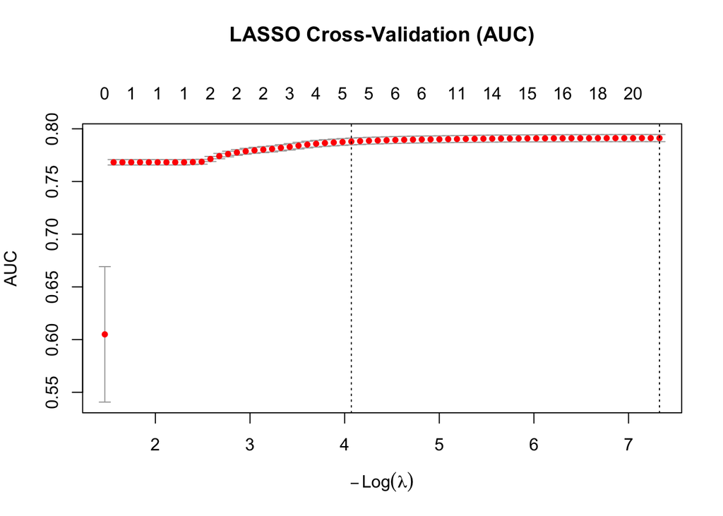

```r
X_train <- model.matrix(hypertension ~ ., training_data)[, -1]
y_train <- ifelse(training_data$hypertension == "Hypertensive", 1, 0)
X_test  <- model.matrix(hypertension ~ ., testing_data)[, -1]
y_test  <- ifelse(testing_data$hypertension == "Hypertensive", 1, 0)

set.seed(123)
lasso_cv <- cv.glmnet(X_train, y_train,
                      family       = "binomial",
                      alpha        = 1,
                      nfolds       = 5,
                      type.measure = "auc")

par(mar = c(5, 4, 6, 2))
plot(lasso_cv, main = "")
title(main = "LASSO Cross-Validation (AUC)", line = 4)
```

```r
cat("Best lambda (lambda.min):", round(lasso_cv$lambda.min, 5), "\n")
```

```
## Best lambda (lambda.min): 0.00066
```

```r
cat("\nNon-zero coefficients at lambda.min:\n")
```

```
##
## Non-zero coefficients at lambda.min:
```

```r
coef(lasso_cv, s = "lambda.min")
```

```
## 23 x 1 sparse Matrix of class "dgCMatrix"
##                                    lambda.min
## (Intercept)                     -4.4007491860
## PC1                             -0.0213034277
## PC2                             -0.0069637866
## SDDSRVYR                         0.0004813978
## RIDAGEYR                         0.0569616281
## RIAGENDR2                       -0.3871712574
## race2                           -0.0272056291
## race3                            0.0708257904
## race4                            0.5164965380
## race5                            0.3175639562
## race6                            0.2840606043
## race7                            0.3711001663
## DMDEDUC22                        0.0618661989
## DMDEDUC23                        0.0453272041
## DMDEDUC24                       -0.0106766917
## DMDEDUC25                       -0.2096106214
## DMDEDUC27                        0.3070303249
## DMDEDUC29                        0.1870300091
## INDFMPIR                         .
## smoke_statusFormer              -0.0607015204
## smoke_statusCurrent (some days)  .
## smoke_statusCurrent (daily)      0.0391198177
## BMXBMI                           0.0575584598
```

```r
lasso_probs <- predict(lasso_cv, X_test, s = "lambda.min", type = "response")
lasso_roc   <- roc(y_test, as.vector(lasso_probs))
cat("\nLASSO AUC:", round(auc(lasso_roc), 4), "\n")
```

```
##
## LASSO AUC: 0.7979
```

In the LASSO model, only two features were shrunk to zero: the variable indicating a current smoker (some days) and the income-to-poverty ratio. Notably, this model retained both PC1 and PC2. The AUC’s across the standard logistic regression model and LASSO are nearly identical (0.798 and 0.7979, respectively). Since LASSO only dropped two weak predictors, the information loss was minimal compared to the baseline model.

## 4.6 Random Forest

```r
set.seed(123)
rf_model <- randomForest(
  hypertension ~ .,
  data       = training_data,
  ntree      = 500,
  mtry       = floor(sqrt(ncol(training_data) - 1)),
  importance = TRUE
)

cat("OOB error rate:", round(rf_model$err.rate[500, "OOB"] * 100, 2), "%\n")
```

```
## OOB error rate: 27.82 %
```

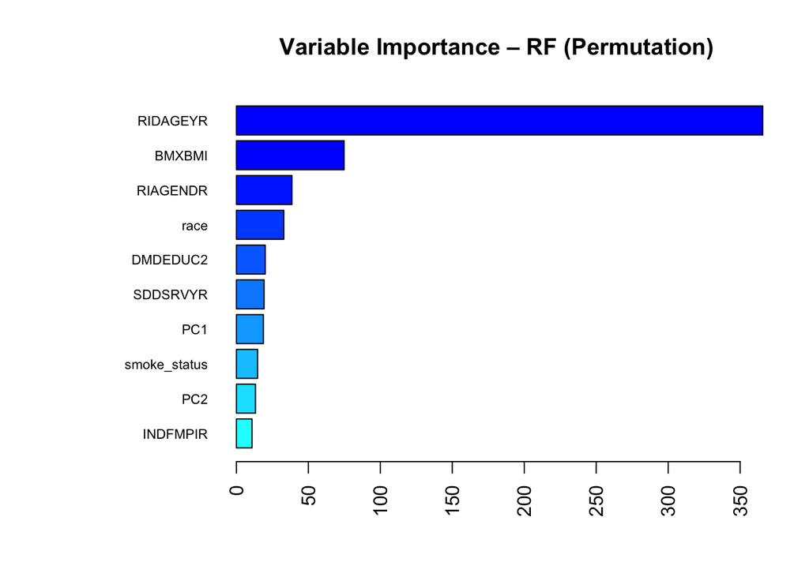

Variable importance from the Random Forest model (permutation-based).

```r
imp <- sort(importance(rf_model)[, "MeanDecreaseAccuracy"], decreasing = FALSE)

par(mar = c(5, 10, 4, 2))
barplot(imp,
        las       = 2,
        horiz     = TRUE,
        cex.names = 0.7,
        col       = colorRampPalette(colors = c("cyan", "blue"))(length(imp)),
        main      = "Variable Importance – RF (Permutation)")
```

```r
rf_pred  <- predict(rf_model, testing_data)
rf_probs <- predict(rf_model, testing_data, type = "prob")[, "Hypertensive"]

confusionMatrix(rf_pred, testing_data$hypertension, positive = "Hypertensive")
```

```
## Confusion Matrix and Statistics
##
##                   Reference
## Prediction         Not hypertensive Hypertensive
##   Not hypertensive             5933         1958
##   Hypertensive                 2250         5570
##
##                Accuracy : 0.7322
##                  95% CI : (0.7252, 0.7391)
##     No Information Rate : 0.5208
##     P-Value [Acc > NIR] : < 2.2e-16
##
##                   Kappa : 0.4642
##
##  Mcnemar's Test P-Value : 7.259e-06
##
##             Sensitivity : 0.7399
##             Specificity : 0.7250
##          Pos Pred Value : 0.7123
##          Neg Pred Value : 0.7519
##              Prevalence : 0.4792
##          Detection Rate : 0.3545
##    Detection Prevalence : 0.4977
##       Balanced Accuracy : 0.7325
##
##        'Positive' Class : Hypertensive
##
```

```r
rf_roc <- roc(testing_data$hypertension, rf_probs,
              levels = c("Not hypertensive", "Hypertensive"))
cat("Random Forest AUC:", round(auc(rf_roc), 4), "\n")
```

```
## Random Forest AUC: 0.7969
```

The OOB error rate from the training set is reported above. The variable importance plots show the permutation-based importance for all predictors.

After predicting on the test set, the AUC is 0.797, which is comparable to the AUC for logistic regression. Of all truly hypertensive people, the model correctly flags 74%. Of all truly non-hypertensive people, 72.5% are correctly classified. Sensitivity and specificity are nearly equal, meaning that the model performs similarly across both classes. The out of bag error rate and test-set accuracy indicates that there is no meaningful overfitting of the data. The dietary PC1 and PC2 are ranked as the 7th and 9th most important predictors in the model out of 10 total predictors. Age, BMI, and sex dominant the variable importance plot.

## 4.7 XGBoost

Five-fold cross-validation selected the optimal number of boosting rounds.

```r
dtrain <- xgb.DMatrix(X_train, label = y_train)
dtest  <- xgb.DMatrix(X_test,  label = y_test)

params <- list(
  objective        = "binary:logistic",
  eval_metric      = "auc",
  max_depth        = 4,
  eta              = 0.05,
  subsample        = 0.8,
  colsample_bytree = 0.8
)

set.seed(123)
xgb_cv <- xgb.cv(
  params                = params,
  data                  = dtrain,
  nrounds               = 500,
  nfold                 = 5,
  early_stopping_rounds = 30,
  maximize              = TRUE,
  verbose               = 0
)
```

```r
best_nrounds <- which.max(xgb_cv$evaluation_log$test_auc_mean)

xgb_model <- xgb.train(
  params  = params,
  data    = dtrain,
  nrounds = best_nrounds,
  evals   = list(train = dtrain, test = dtest),
  verbose = 0
)
```

```r
cat("Best number of boosting rounds:", best_nrounds, "\n")
```

```
## Best number of boosting rounds: 137
```

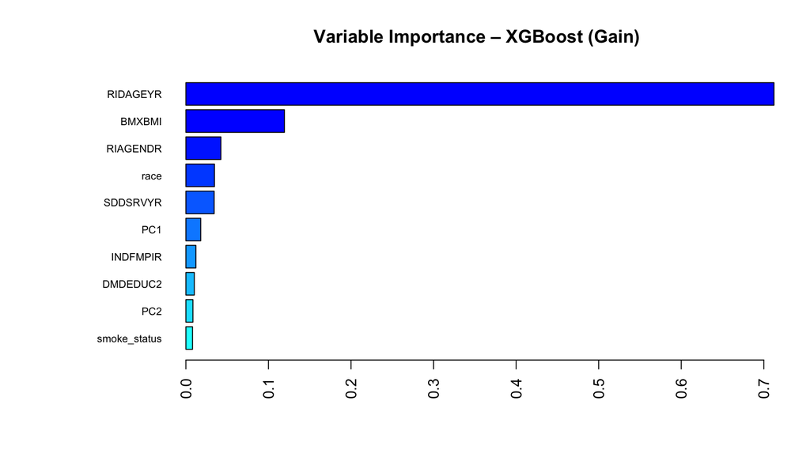

Variable importance from the XGBoost model (gain-based, aggregated to variable level).

```r
xgb_imp <- xgb.importance(model = xgb_model)

# aggregate dummy columns back to the general variable
# to match RF ouput
factor_vars <- c("race", "RIAGENDR", "DMDEDUC2", "smoke_status")
xgb_imp$Variable <- xgb_imp$Feature
for (v in factor_vars) {
  xgb_imp$Variable[startsWith(xgb_imp$Feature, v)] <- v
}

xgb_imp_agg    <- aggregate(Gain ~ Variable, data = xgb_imp, FUN = sum)
xgb_imp_sorted <- xgb_imp_agg[order(xgb_imp_agg$Gain), ]

par(mar = c(5, 10, 4, 2))
barplot(xgb_imp_sorted$Gain,
        names.arg = xgb_imp_sorted$Variable,
        las       = 2,
        horiz     = TRUE,
        cex.names = 0.7,
        col       = colorRampPalette(colors = c("cyan", "blue"))(nrow(xgb_imp_sorted)),
        main      = "Variable Importance – XGBoost (Gain)")
```

```r
xgb_probs <- predict(xgb_model, dtest)
xgb_roc   <- roc(y_test, xgb_probs)
cat("XGBoost AUC:", round(auc(xgb_roc), 4), "\n")
```

```
## XGBoost AUC: 0.8048
```

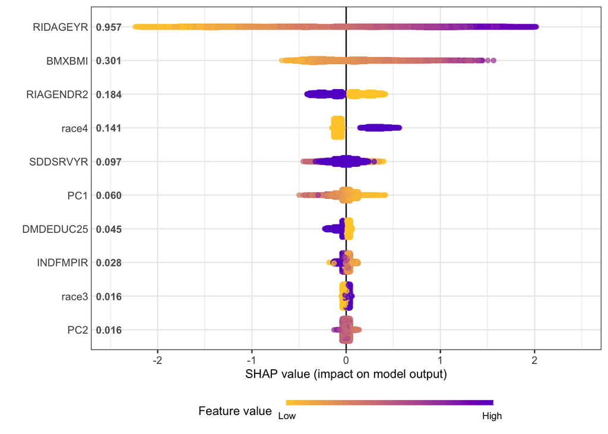

SHAP summary plot showing direction and magnitude of feature contributions.

```r
shap_values <- shap.values(xgb_model, X_train = X_train)
shap.plot.summary.wrap1(xgb_model, X = X_train, top_n = 10)
```

The five-fold cross-validation selected 137 boosting rounds. The variance importance plot provides similar results to that of the Random Forest plot, where age, BMI, and sex are by far the most important predictors. The dietary intake variable, PC1, was the 6th most important predictor compared to being the 7th in the Random Forest plot.

## 4.8 Model Comparison

```r
auc_table <- tibble(
  Model       = c("Logistic Regression", "LASSO", "Random Forest", "XGBoost"),
  AUC         = round(c(auc(log_roc), auc(lasso_roc), auc(rf_roc), auc(xgb_roc)), 4),
  Sensitivity = c(
    round(coords(log_roc,   "best", ret = "sensitivity")$sensitivity, 4),
    round(coords(lasso_roc, "best", ret = "sensitivity")$sensitivity, 4),
    0.7399,
    round(coords(xgb_roc,  "best", ret = "sensitivity")$sensitivity, 4)
  ),
  Specificity = c(
    round(coords(log_roc,   "best", ret = "specificity")$specificity, 4),
    round(coords(lasso_roc, "best", ret = "specificity")$specificity, 4),
    0.7250,
    round(coords(xgb_roc,  "best", ret = "specificity")$specificity, 4)
  )
)

knitr::kable(auc_table, caption = "Model performance summary (test set). Sensitivity and specificity computed at the optimal threshold via Youden's J.") |>
  kable_styling(bootstrap_options = c("striped", "hover", "condensed"),
                full_width = FALSE, position = "left") |>
  row_spec(which(auc_table$Model == "Logistic Regression"),
           bold = TRUE, background = "#eaf3fb")
```

Model performance summary (test set). Sensitivity and specificity computed at the optimal threshold via Youden’s J.

| Model | AUC | Sensitivity | Specificity |
| --- | --- | --- | --- |
| Logistic Regression | 0.7980 | 0.7760 | 0.6995 |
| LASSO | 0.7979 | 0.7897 | 0.6873 |
| Random Forest | 0.7969 | 0.7399 | 0.7250 |
| XGBoost | 0.8048 | 0.7735 | 0.7027 |

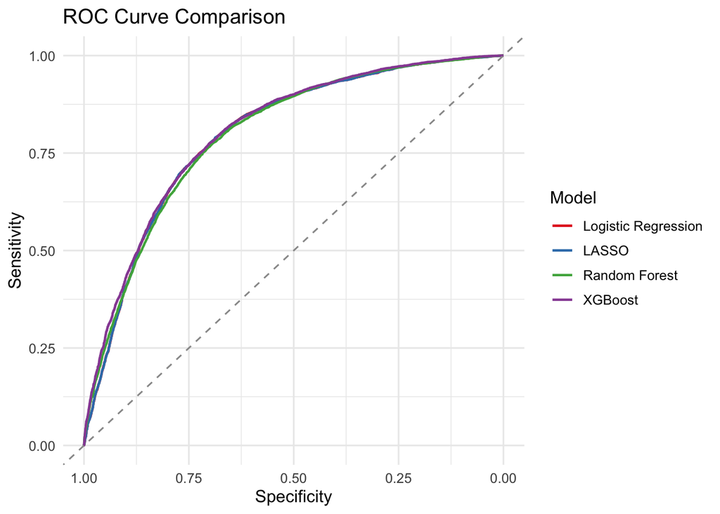

ROC curves for all four models on the test set.

```r
roc_list <- list(
  "Logistic Regression" = log_roc,
  "LASSO"               = lasso_roc,
  "Random Forest"       = rf_roc,
  "XGBoost"             = xgb_roc
)

ggroc(roc_list, size = 0.8) +
  geom_abline(slope = 1, intercept = 1, linetype = "dashed", color = "gray60") +
  scale_color_manual(values = c("#e41a1c", "#377eb8", "#4daf4a", "#984ea3")) +
  theme_minimal(base_size = 12) +
  labs(title = "ROC Curve Comparison", color = "Model",
       x = "Specificity", y = "Sensitivity")
```

# 5 Full Interpretation

This analysis examined whether PCA-derived dietary pattern scores can help predict hypertension status in a held-out test set of U.S. adults, in addition to key demographic and behavioral covariates. Across all four models, dietary patterns, particularly dietary volume (PC1), contributed independently to hypertension prediction, but, according to the variable importance diagnostic for Random Forest and XGBoost, their effect was substantially smaller than that of age, BMI, and sex.

PC1 (dietary volume) was a significant predictor in logistic regression and ranked 7th of 10 predictors in Random Forest and 6th of 10 predictors in XGBoost, with a mean |SHAP| of 0.060. PC2 (diet quality) was not statistically significant in logistic regression and ranked 9th in both XGBoost (mean |SHAP| = 0.016) and Random Forest, suggesting that dietary composition, as captured by a single 24-hour recall, has minimal independent predictive value once total intake volume and established risk factors are accounted for. LASSO retained both PC1 and PC2, which further confirmed that they carry some slight signal, but the magnitude is small relative to lifestyle and demographic predictors.

All four models achieved similar discriminative performance (AUC 0.797–0.805), suggesting that the relationships between predictors and hypertension in this dataset are largely linear and additive. Logistic regression was selected as the preferred model given its comparable performance, interpretability, and clinical transparency. The consistency of findings across methods strengthens confidence in the identified predictors.

## 5.1 Limitations

1. The biggest limitation is the cross-sectional design of NHANES. Because of this, temporality between diet and hypertension cannot be established. There is the potential that one could have received their hypertension diagnosis and changed the way they eat, which could lead to a deflation of the dietary coefficients. We cannot be certain whether dietary patterns are causing a change in hypertension diagnosis, given the nature of the dataset. These models should be replicated in a longitudinal study and compared to these results.
2. Another key limitation is the absence of survey weights. These results should therefore be interpreted as sample-based rather than population-representative estimates. Future work could apply the NHANES’s survey design weights for any population-level inferences.
3. The dietary patterns are based on a single 24-hour dietary recall, which may not reflect an individual’s habitual intake.
4. NHANES is a U.S. specific dataset and may not be generalizable to populations outside of the U.S..
5. There are some predictors established in past literature that were not included in this study. Physical activity and alcohol consumption should be considered in the future, but these variables had extreme missingness (>70%) in this dataset and were therefore excluded.

## 5.2 Ethical Considerations

This analysis has several ethical considerations that should be taken into account.

First, this is an observational prediction model, not a clinical tool. The model should not be used to screen or label individuals as hypertensive in any applied setting. It is intended to explore the predictive role of dietary patterns in a research context. Misapplication of a model like this in clinical or insurance contexts could cause direct harm.

Second, race and ethnicity are included as predictors, and several racial groups show significantly elevated hypertension risk relative to the reference group. These associations reflect real epidemiological patterns rooted in structural racism, socioeconomic inequity, and differential access to care, and should not be misinterpreted as inherent biological differences. Reporting these findings without that context risks reinforcing deficit narratives about minority communities. Any interpretation of race-related model outputs, particularly in a clinical setting, must be accompanied by the acknowledgment of these structural determinants.

Third, if a model like this were deployed for population-level risk stratification, the differential predictive performance across specific demographic subgroups could exacerbate existing health disparities by systematically misclassifying certain groups. A fairness audit across different subgroups in race, income, and sex should be required before any model is implemented.

## 5.3 References

- Chowdhury, M. Z. I., Naeem, I., Quan, H., Leung, A. A., Sikdar, K. C., O’Beirne, M., & Turin, T. C. (2022). Prediction of hypertension using traditional regression and machine learning models: A systematic review and meta-analysis. PloS one, 17(4), e0266334. https://doi.org/10.1371/journal.pone.0266334
- Sifat, I. K., & Kibria, M. K. (2024). Optimizing hypertension prediction using ensemble learning approaches. PloS one, 19(12), e0315865. https://doi.org/10.1371/journal.pone.0315865
- QuickStats: Age-Adjusted Percentage of Adults Aged ≥18 Years with Hypertension, by Sex and Race and Ethnicity — United States, August 2021–August 2023. MMWR Morb Mortal Wkly Rep 2024;73:1110. DOI: http://dx.doi.org/10.15585/mmwr.mm7348a5